# Exploratory Data Analysis

# Prosper Loan Data by Katherine Perry

## Introduction

Prosper is an American peer-to-peer lending platform. The site allows borrowers to post a listing for a chosen loan amount and purpose. Investors are then given the opportunity to invest in loans of their choice. Prosper collects data on borrower details and provides risk ratings for investors (see below for a full list of variables and structure of the data).

I’m interested in the concept of peer-to-peer lending and ultimately would like to know if peer-to-peer lending is a good investment. In order to assess this question I will perform an exploratory data anlysis on the Prosper Loan Data.

The dataset contains information on 81 variables for almost 114,000 loans.

```
##  [1] "ListingKey"
##  [2] "ListingNumber"
##  [3] "ListingCreationDate"
##  [4] "CreditGrade"
##  [5] "Term"
##  [6] "LoanStatus"
##  [7] "ClosedDate"
##  [8] "BorrowerAPR"
##  [9] "BorrowerRate"
## [10] "LenderYield"
## [11] "EstimatedEffectiveYield"
## [12] "EstimatedLoss"
## [13] "EstimatedReturn"
## [14] "ProsperRating..numeric."
## [15] "ProsperRating..Alpha."
```

[output cut: 66 more lines]

```
## 'data.frame':    113937 obs. of  81 variables:
##  $ ListingKey                         : Factor w/ 113066 levels "00003546482094282EF90E5",..: 7180 7193 6647 6669 6686 6689 6699 6706 6687 6687 ...
##  $ ListingNumber                      : int  193129 1209647 81716 658116 909464 1074836 750899 768193 1023355 1023355 ...
##  $ ListingCreationDate                : Factor w/ 113064 levels "2005-11-09 20:44:28.847000000",..: 14184 111894 6429 64760 85967 100310 72556 74019 97834 97834 ...
##  $ CreditGrade                        : Factor w/ 9 levels "","A","AA","B",..: 5 1 8 1 1 1 1 1 1 1 ...
##  $ Term                               : int  36 36 36 36 36 60 36 36 36 36 ...
##  $ LoanStatus                         : Factor w/ 12 levels "Cancelled","Chargedoff",..: 3 4 3 4 4 4 4 4 4 4 ...
##  $ ClosedDate                         : Factor w/ 2803 levels "","2005-11-25 00:00:00",..: 1138 1 1263 1 1 1 1 1 1 1 ...
##  $ BorrowerAPR                        : num  0.165 0.12 0.283 0.125 0.246 ...
##  $ BorrowerRate                       : num  0.158 0.092 0.275 0.0974 0.2085 ...
##  $ LenderYield                        : num  0.138 0.082 0.24 0.0874 0.1985 ...
##  $ EstimatedEffectiveYield            : num  NA 0.0796 NA 0.0849 0.1832 ...
##  $ EstimatedLoss                      : num  NA 0.0249 NA 0.0249 0.0925 ...
##  $ EstimatedReturn                    : num  NA 0.0547 NA 0.06 0.0907 ...
##  $ ProsperRating..numeric.            : int  NA 6 NA 6 3 5 2 4 7 7 ...
```

[output cut: 67 more lines]

## Initial Key questions:

What is the risk of investing in Prosper Loans?

What is the potential yield of investing in Prosper Loans?

## Univariate Analysis

Firstly I’ll investigate the variables to gain a better understanding of the data. I’ll have a focus on characteristics of the borrower and the return from the loans.

**Listing Category**

I’ll start by finding out why people borrow from Prosper.

More than half of the loans in the dataset are for debt consolidation. There are also a high number of loans with a category of not available and other. Given these three categories account for such a high proportion of loans I won’t be focussing on the listing category variable in this analysis.

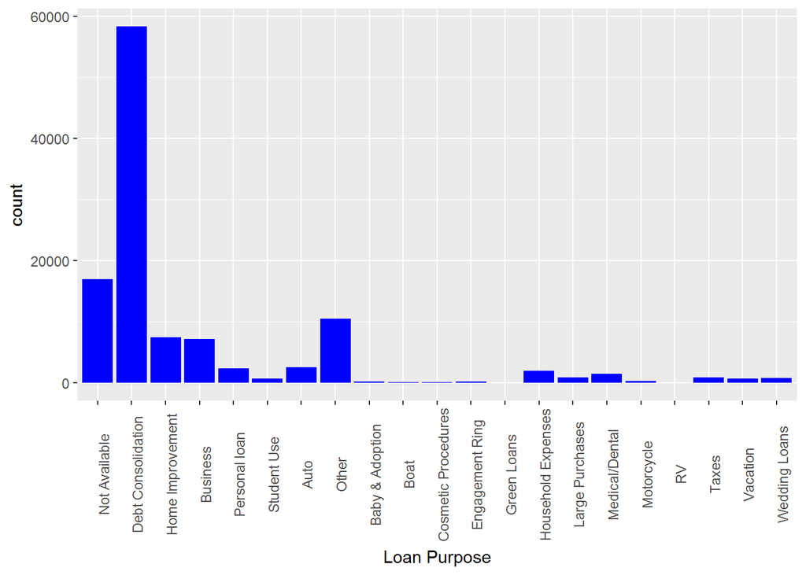

```
##
##       Not Available  Debt Consolidation    Home Improvement
##               16965               58308                7433
##            Business       Personal loan         Student Use
##                7189                2395                 756
##                Auto               Other     Baby & Adoption
##                2572               10494                 199
##                Boat Cosmetic Procedures     Engagement Ring
##                  85                  91                 217
##         Green Loans  Household Expenses     Large Purchases
##                  59                1996                 876
##      Medical/Dental          Motorcycle                  RV
##                1522                 304                  52
##               Taxes            Vacation       Wedding Loans
##                 885                 768                 771
```

**Employment Status**

Most people in the dataset are employed (including full-time, part-time and self-employed), with only 835 observations for not employed, 795 for retired and 3,806 other. There are 2,255 entries with a blank status and 5,347 with the employment status ‘Not available’. I would like to find out if employed borrowers have a lower risk rating investment than their unemployed counter parts.

In future plots I’ll combine and treat employed as one category to include employed, full-time and part-time. I’ll leave self-employed as a separate category as there might be some interesting characteristcs of loans where the borrower is self-employed.

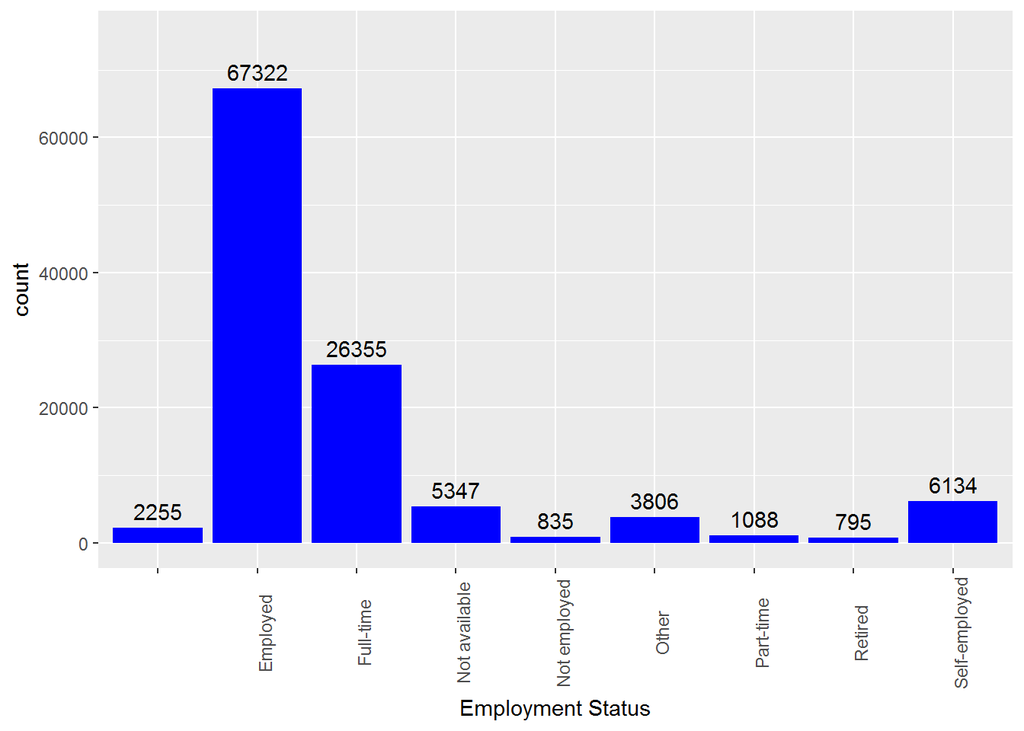

**Employment Duration**

The average employment status duration is 8 years while the first quartile is 2.2 years. There are two possibilities that come to mind: people who borrow through Prosper are often changing their employment status; or people typically borrow early into their employment status. For example self-employed borrowers borrow during the early stages of their business.

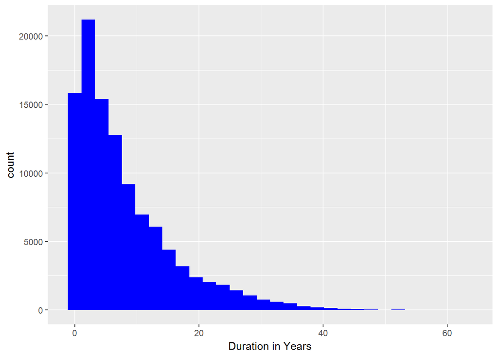

```
##    Min. 1st Qu.  Median    Mean 3rd Qu.    Max.    NA's
##   0.000   2.167   5.583   8.006  11.420  62.920    7625
```

**Stated Monthly Income**

The median stated monthly income is $4,667 while the average monthly income is $5,608. The identified outlier generates a higher average, but there are such a high number of observations that the outlier doesn’t have as much of an effect as it would have with fewer observations.

```
##    Min. 1st Qu.  Median    Mean 3rd Qu.    Max.
##       0    3200    4667    5608    6825 1750000
```

```
## IncomeVerifiable
## False  True
##     1     0
```

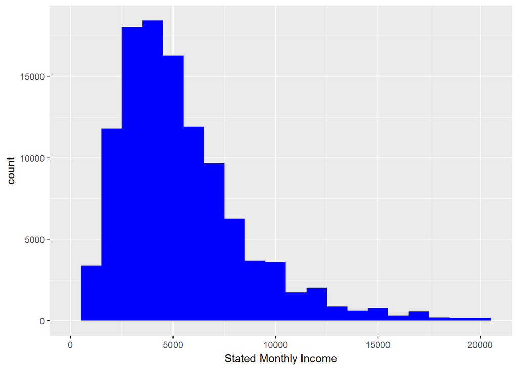

**Income Range**

Albiet a low number of loans, it is interesting that some people who got a loan have zero income or are not employed. I am interested in finding out what people who have $0 income got their loan for and what is the risk rating of their loan.

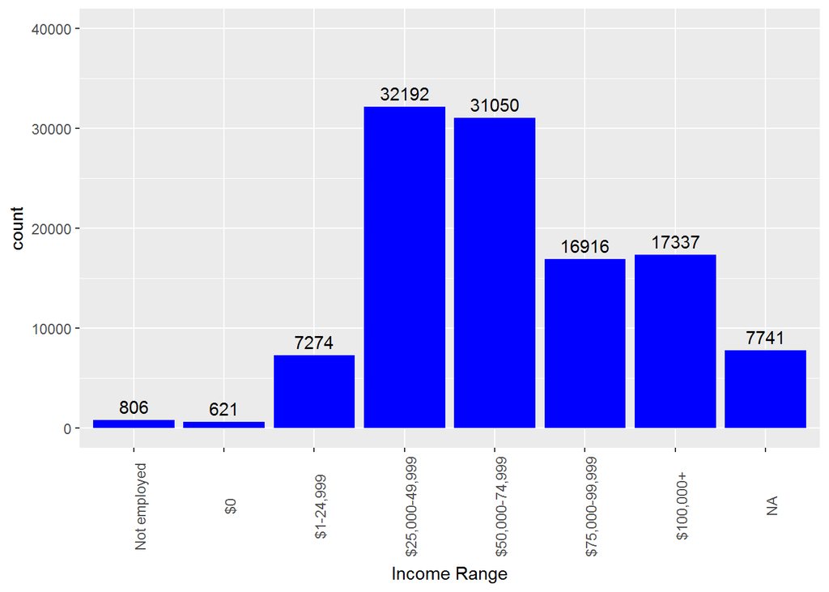

**Debt To Income Ratio**

Around 60% of loans have a debt to income ratio of less than 0.25, with less than 1% (799 loans) recording a debt to income ratio of more than 1. I will be interested to see if the debt to income ratio has an effect on the risk rating of the loan or on the loan status.

For future use I created a new variable. This variable groups the debt to income ratio into five buckets. This will allow me to analyse the charateristics of borrowers with a similar debt to income ratio.

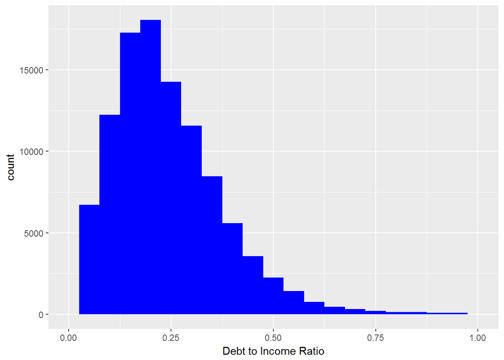

```r
ggplot(aes(x = DebtToIncomeRatio), data = loanData) +
  geom_histogram(binwidth = 0.05, fill = "blue") +
  xlim(0,1) +
  xlab("Debt to Income Ratio")
```

```r
#Cuts the debt to income ratio into bands to be able to analyse borrowers by debt to income ratio group

loanData$DTI <- cut(loanData$DebtToIncomeRatio, breaks = c(-Inf, 0.25, 0.5, 0.75, 1, Inf), labels = c("below 0.25", "0.25-0.5", "0.5-0.75","0.75-1", "1+"))

table(loanData$DTI)
```

```
##
## below 0.25   0.25-0.5   0.5-0.75     0.75-1         1+
##      63959      36160       3892        573        799
```

**Loan Status**

Most of the data is for loans with a loan status of current or completed. There were almost 12,000 loans charged off. I will look to see if there are any contributing factors to a loan being completed or charged off so that I could aim to invest in loans which are more likely to complete. There are also around 5,000 loans which have defaulted and 2,000 loans that are past due. I’m interested to see if there are common characteristics of these loans.

In future plots I will combine the loans with a status of Past Due and treat them as one category.

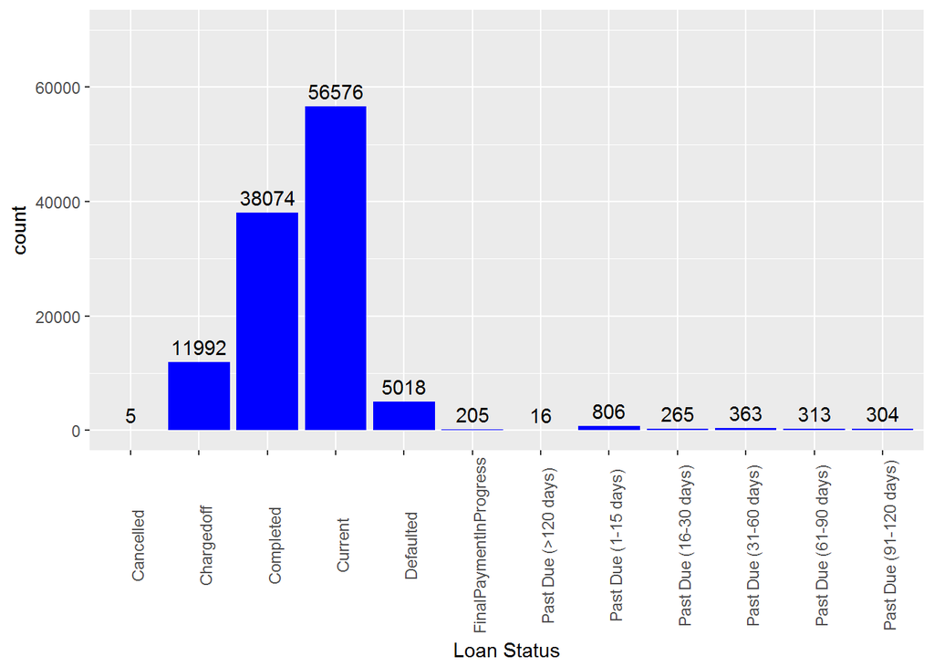

**Loan Amount**

The median loan amount is for $6,500 while the maximum loan amount is $35,000. Based on information from the Prosper website, it appears that $35,000 is the maximum allowable loan amount.

We can see peaks in the data at certain points that correspond with nice round numbers like 10,000 and 15,000. It might be that borrowers are asking for more than they need and are rounding up to the nearest $5,000 increment.

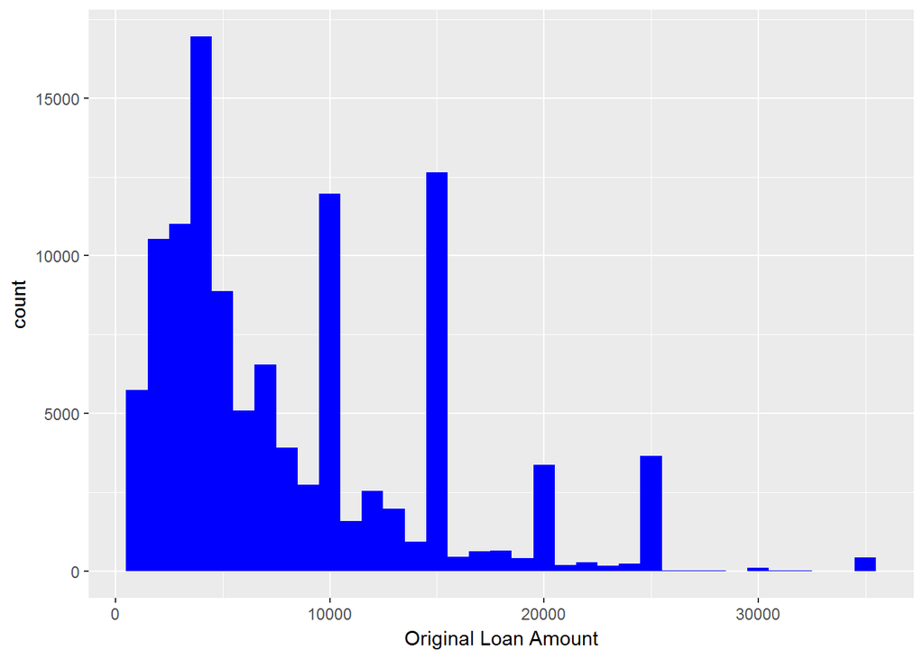

```
##    Min. 1st Qu.  Median    Mean 3rd Qu.    Max.
##    1000    4000    6500    8337   12000   35000
```

**Prosper Rating and Score**

According to the Prosper website the Prosper Rating assesses the estimated average annualized loss rate range with AA as the lowest risk and HR as the highest risk. The Prosper rating only applies to loans after July 2009.

The ratings distribution follows a relatively normal distribution with loans rated ‘C’ recording the highest number of loans at 18,345. I am interested in what borrower characteristics result in a loan with a high Prosper rating. I am also interested in investigating if loans with a higher rating have a higher proportion of completed loans and if a higher risk loan has a higher return.

Most Prosper loans have a score between 4 and 8. The Prosper score reflects borrowers with similar characteristics. I’m intested to find out what the characteristics generate a good Prosper score.

Loans with a score of 1 represent the highest risk with 11 representing the lowest risk loans.

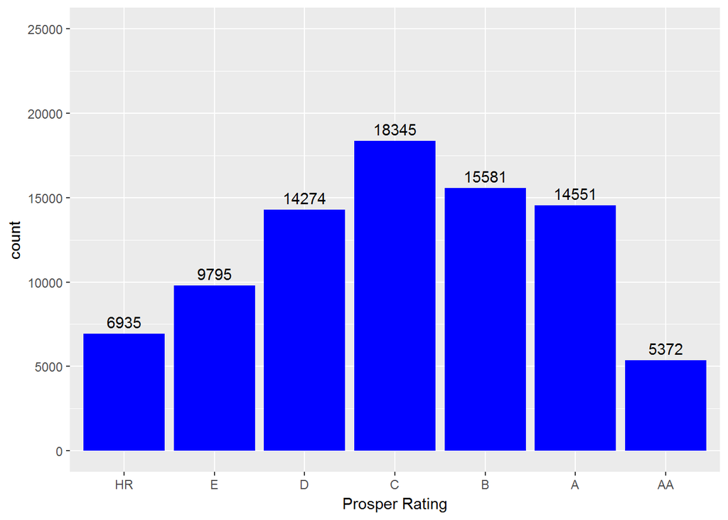

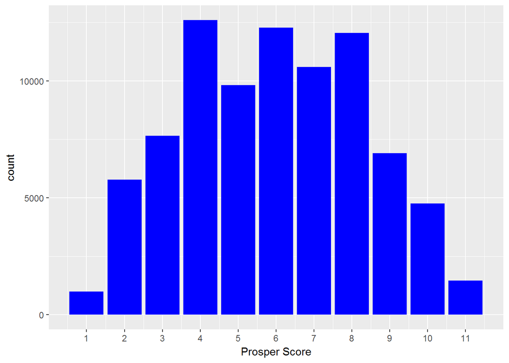

**Lender Yield and Borrower Rate**

22 loans reported having either 0 or negative lender yield. This makes up only a tiny porportion of the 113,937 loans which means for any given loan you are likely to achieve some yield. The average lender yield is 18.27%. There is a spike in the number of loans with a lender yield of just over 30%.

I will look into what loan characteristics result in a higher or lower lender yield and if there is risk associated with loans with a higher lender yield.

The lender yield is equal to the interest rate on the loan less the servicing fee. As such, it is not surprising to discover a corresponding spike in the borrower rate just above the 30% rate. There may be a default borrower rate if certain criteria are met, resulting in the spike.

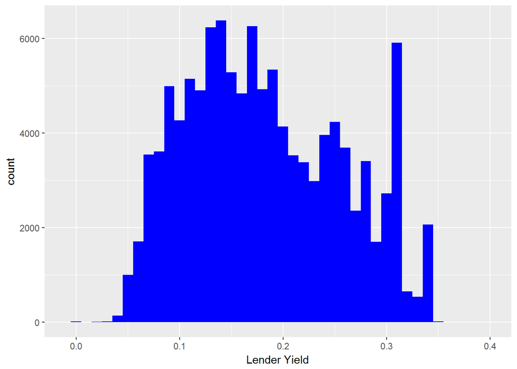

```
##    Min. 1st Qu.  Median    Mean 3rd Qu.    Max.
## -0.0100  0.1242  0.1730  0.1827  0.2400  0.4925
```

```
## LenderYield
##   -0.01 -0.0099 -0.0095  -0.005 -0.0029       0
##       5       1       1       4       1      10
```

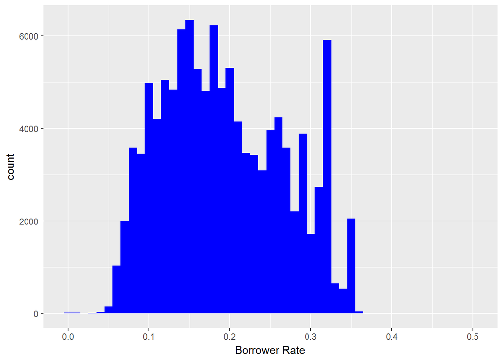

**Estimated Effective Yield**

The estimated effective yield is described as the the borrower interest rate minus the servicing fee, minus uncollected interest on charge-offs, plus estimated collected late fees. The estimated effective yield is only available for loans after 2009.

I will be intested to see if the estimated effective yield accurately predicts the lender yield.

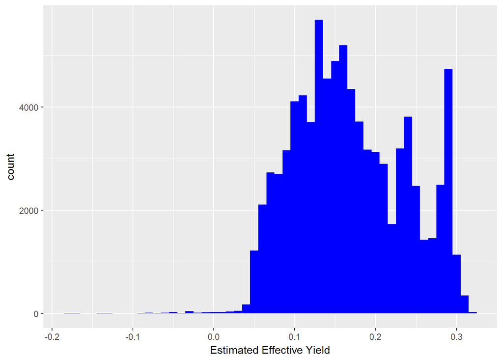

**Loan Timing**

I used the lubridate package to split the loan origination date data into day, month and year. Looking at the number of loans per year I noticed dips in the data. I then pulled the information by year and month to try and see if this offers more information. From this I can see that we don’t have the full year of information for 2005 and 2014 and there is a clear break between 2008 and 2009.

After falling to 2009, the number of loans with Prosper increased to 2013. The significant drop in the number of loans in 2014 is because the Prosper Loan dataset used for this project only has data till March 2014. Prosper was founded in 2005 which is why we have only limited data for 2005. Prosper Loans increased in popularity through 2006 and 2007. In 2008 it appears Prosper temporarily closed their doors, relaunching in 2009. Because of these gaps in the data it is somewhat difficult to draw information about the loan characteristics over time.

Limitations aside, when we look at the number of loans by month it appears that leading up to Christmas and in the New Year is a popular time of year to borrow.

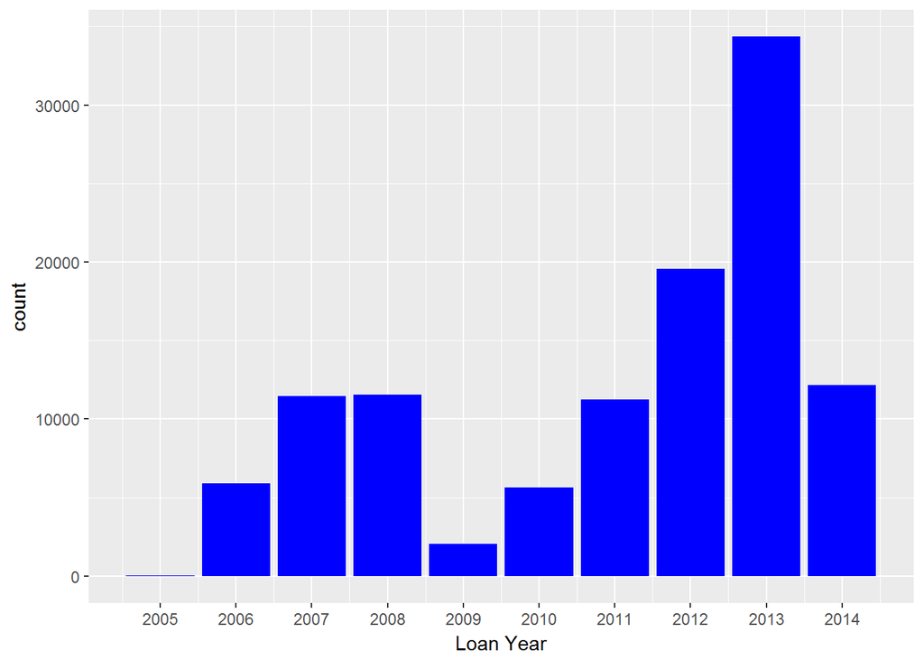

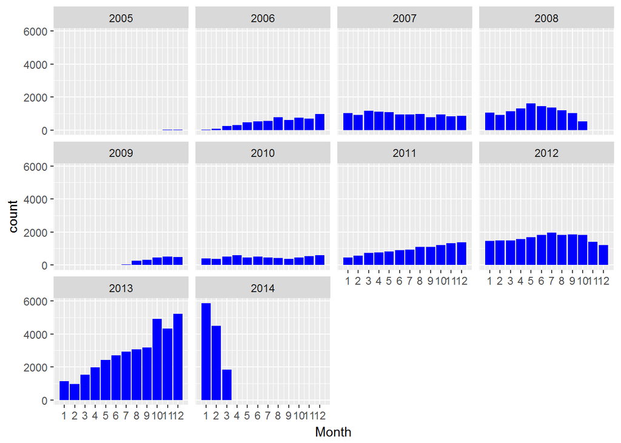

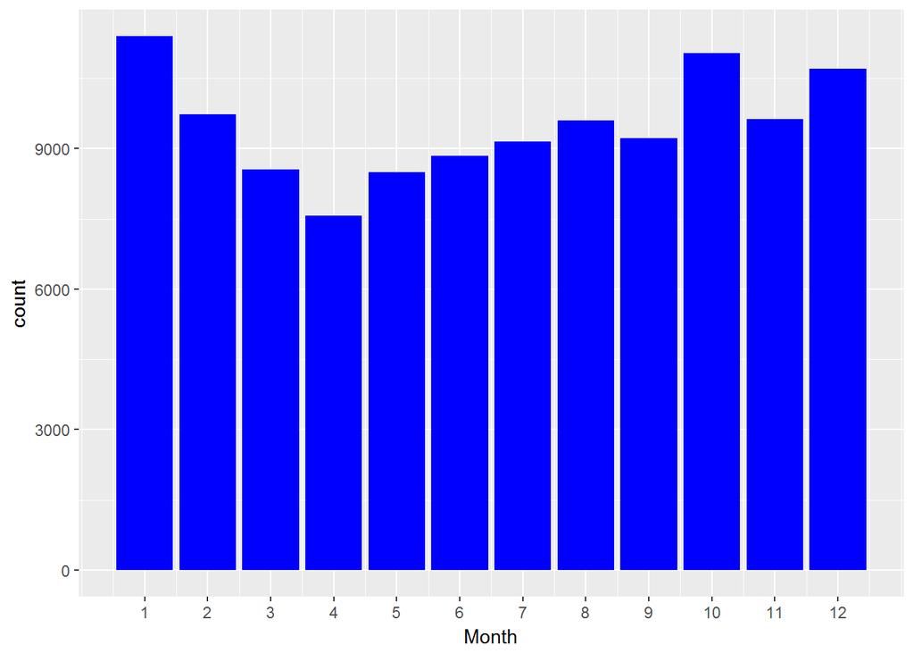

# Bivariate Analysis

To start the bivariate analysis I’ll use ggpairs to look at variables I found intersting in the univariate analysis to see if anything stands out.

Based on the output I’ll look further into the employment status by lender yield and the income range by lender yield.

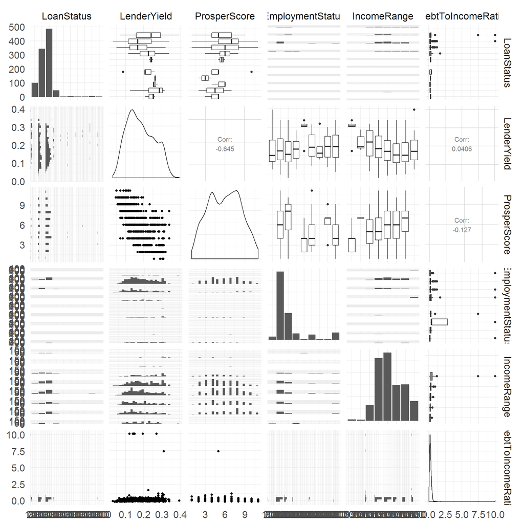

**Why do people borrow money from Prosper?**

In the univariate section of this analysis we discovered that most people borrow with Prosper for debt consolidation (and to a lesser extent ‘not available’ and ‘other’). When we spilt the information by income range we can see it holds true for most income ranges. Debt consolidation accounts for more than half of loans when borrowers have an income of more than $25,000.

Borrowers who are not employed or with $0 income recorded a higher proprotion of borrowers who borrowed money for business reasons (12% and 25% of loans respectively). A significantly higher proportion (17%) of borrowers with $0 income borrowed for a personal loan, compared to 5% or less of borrowers in other income ranges.

The table below shows the proportion of borrowers in a income range by their listing category. Note columns may not add to 100% due to rounding.

Income Range by Category

| ListingCategory | $0 | $1-24,999 | $100,000+ | $25,000-49,999 | $50,000-74,999 | $75,000-99,999 | Not employed |
| --- | --- | --- | --- | --- | --- | --- | --- |
| Auto | 0 | 5 | 1 | 3 | 2 | 2 | 3 |
| Baby & Adoption | 0 | 0 | 0 | 0 | 0 | 0 | 0 |
| Boat | 0 | 0 | 0 | 0 | 0 | 0 | 0 |
| Business | 25 | 7 | 8 | 6 | 6 | 7 | 12 |
| Cosmetic Procedures | 0 | 0 | 0 | 0 | 0 | 0 | 0 |
| Debt Consolidation | 16 | 39 | 58 | 52 | 58 | 59 | 33 |
| Engagement Ring | 0 | 0 | 0 | 0 | 0 | 0 | 0 |
| Green Loans | 0 | 0 | 0 | 0 | 0 | 0 | 0 |
| Home Improvement | 3 | 4 | 10 | 6 | 7 | 8 | 4 |
| Household Expenses | 0 | 2 | 2 | 2 | 2 | 2 | 7 |
| Large Purchases | 0 | 1 | 1 | 1 | 1 | 1 | 1 |
| Medical/Dental | 0 | 1 | 1 | 2 | 1 | 1 | 2 |
| Motorcycle | 0 | 1 | 0 | 0 | 0 | 0 | 0 |
| Not Available | 29 | 17 | 5 | 11 | 7 | 6 | 9 |
| Other | 5 | 14 | 8 | 11 | 9 | 9 | 19 |
| Personal loan | 17 | 5 | 1 | 3 | 2 | 1 | 3 |
| RV | 0 | 0 | 0 | 0 | 0 | 0 | 0 |
| Student Use | 5 | 3 | 0 | 1 | 0 | 0 | 5 |
| Taxes | 0 | 0 | 1 | 1 | 1 | 1 | 0 |
| Vacation | 0 | 1 | 1 | 1 | 1 | 1 | 1 |
| Wedding Loans | 0 | 1 | 1 | 1 | 1 | 1 | 0 |

**Do employed borrowers have a lower risk rating?**

As mentioned above, I combined employed, part-time and full-time into one category (employed) to more easily find any patterns in employed borrowers.

Borrowers who are not employed and to a lesser extent retired borrowers carry a higher risk rating. The rating distribution of employed borrowers on average have a higher rating, indicating a lower risk loan.

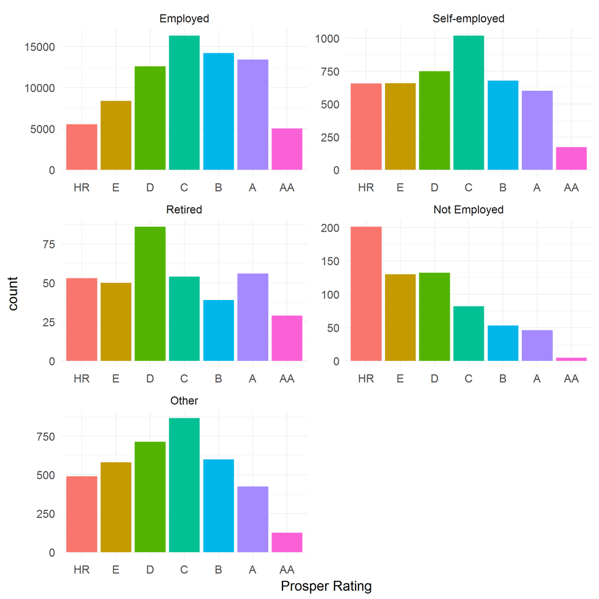

```r
#Categorises employed, part-time and full-time into one category (employed)

loanData$EmploymentCategory <- factor(loanData$EmploymentStatus, labels=c("NA", "Employed", "Employed", "NA","Not Employed", "Other", "Employed", "Retired", "Self-employed"))

#rearranges employment status for better flow of information

loanData$EmploymentCategory <- factor(loanData$EmploymentCategory, levels = c("Employed", "Self-employed", "Retired", "Not Employed", "Other", "NA"))

ggplot(aes(x = ProsperRating..Alpha.), data = subset(loanData, ProsperRating..Alpha. != "NA" & EmploymentCategory != "NA")) +
  facet_wrap(~EmploymentCategory, ncol = 2, scales = "free") +
  geom_bar(aes(fill = ProsperRating..Alpha.), show.legend=F) +
  xlab("Prosper Rating")
```

```r
by(loanData$ProsperRating..numeric., loanData$EmploymentCategory, summary)
```

```
## loanData$EmploymentCategory: Employed
##    Min. 1st Qu.  Median    Mean 3rd Qu.    Max.    NA's
##   1.000   3.000   4.000   4.136   5.000   7.000   19272
## --------------------------------------------------------
## loanData$EmploymentCategory: Self-employed
##    Min. 1st Qu.  Median    Mean 3rd Qu.    Max.    NA's
##   1.000   2.000   4.000   3.639   5.000   7.000    1596
## --------------------------------------------------------
## loanData$EmploymentCategory: Retired
##    Min. 1st Qu.  Median    Mean 3rd Qu.    Max.    NA's
##   1.000   2.000   3.000   3.708   5.000   7.000     428
## --------------------------------------------------------
## loanData$EmploymentCategory: Not Employed
##    Min. 1st Qu.  Median    Mean 3rd Qu.    Max.    NA's
##   1.000   1.000   2.000   2.713   4.000   7.000     186
## --------------------------------------------------------
## loanData$EmploymentCategory: Other
##    Min. 1st Qu.  Median    Mean 3rd Qu.    Max.
##     1.0     2.0     4.0     3.6     5.0     7.0
## --------------------------------------------------------
## loanData$EmploymentCategory: NA
##    Min. 1st Qu.  Median    Mean 3rd Qu.    Max.    NA's
##      NA      NA      NA     NaN      NA      NA    7602
```

**Does the employment status have an effect on the Prosper score?**

Borrowers with an employment status of ‘other’ and ‘self-employed’ appear to have more loans with a higher risk rating (lower score) while ‘retired’ borrowers have more scores with a lower risk (higher score).

It is interesting that retired borrowers have a higher number of borrowers with a Prosper Rating of D, and yet seem to have a high number of borrowers with a high Prosper Score.

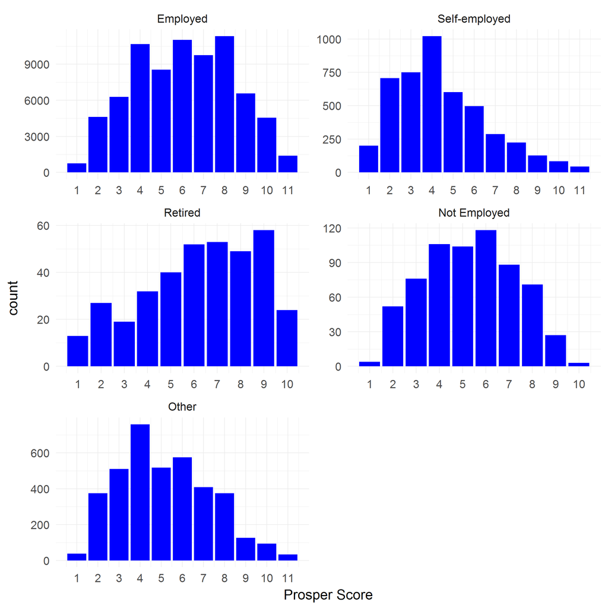

```
## loanData$EmploymentCategory: Employed
##    Min. 1st Qu.  Median    Mean 3rd Qu.    Max.    NA's
##   1.000   4.000   6.000   6.084   8.000  11.000   19272
## --------------------------------------------------------
## loanData$EmploymentCategory: Self-employed
##    Min. 1st Qu.  Median    Mean 3rd Qu.    Max.    NA's
##   1.000   3.000   4.000   4.444   6.000  11.000    1596
## --------------------------------------------------------
## loanData$EmploymentCategory: Retired
##    Min. 1st Qu.  Median    Mean 3rd Qu.    Max.    NA's
##   1.000   5.000   7.000   6.237   8.000  10.000     428
## --------------------------------------------------------
## loanData$EmploymentCategory: Not Employed
##    Min. 1st Qu.  Median    Mean 3rd Qu.    Max.    NA's
##   1.000   4.000   5.000   5.308   7.000  10.000     186
## --------------------------------------------------------
## loanData$EmploymentCategory: Other
##    Min. 1st Qu.  Median    Mean 3rd Qu.    Max.
##   1.000   4.000   5.000   5.167   7.000  11.000
## --------------------------------------------------------
## loanData$EmploymentCategory: NA
##    Min. 1st Qu.  Median    Mean 3rd Qu.    Max.    NA's
##      NA      NA      NA     NaN      NA      NA    7602
```

**Do unemployed borrowers have a higher proportion of loans that are charged off, defaulted or past due?**

Borrowers with an employment status of ‘self-employed’, ‘not employed’ and ‘other’ recorded a higher proportion of loans that were charged off. Borrowers with an employment status of ‘other’ also recorded a significantly higher proportion of loans that are past due. Employed and retired borrowers have a higher proportion of completed loans.

With a relatively high proportion of completed loans it seems that retired borrowers do have less risk as the Prosper score suggests.

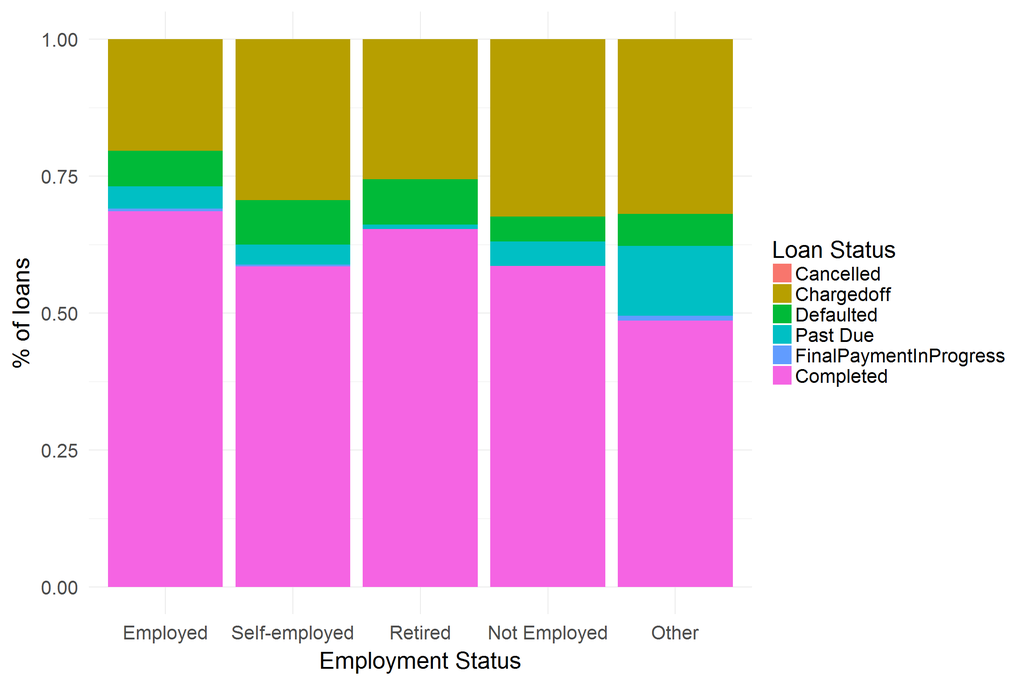

**Do borrowers with higher income have a lower risk loan?**

Borrowers with higher income (more than $75,000) have a higher incident of loans with a Prosper score of 8. When we look at the summary by income range we can see that the average Prosper Score increases with the income range. The average Prosper Score of borrowers who are not employed is similar to borrowers with an income range of $25,000 - $49,999.

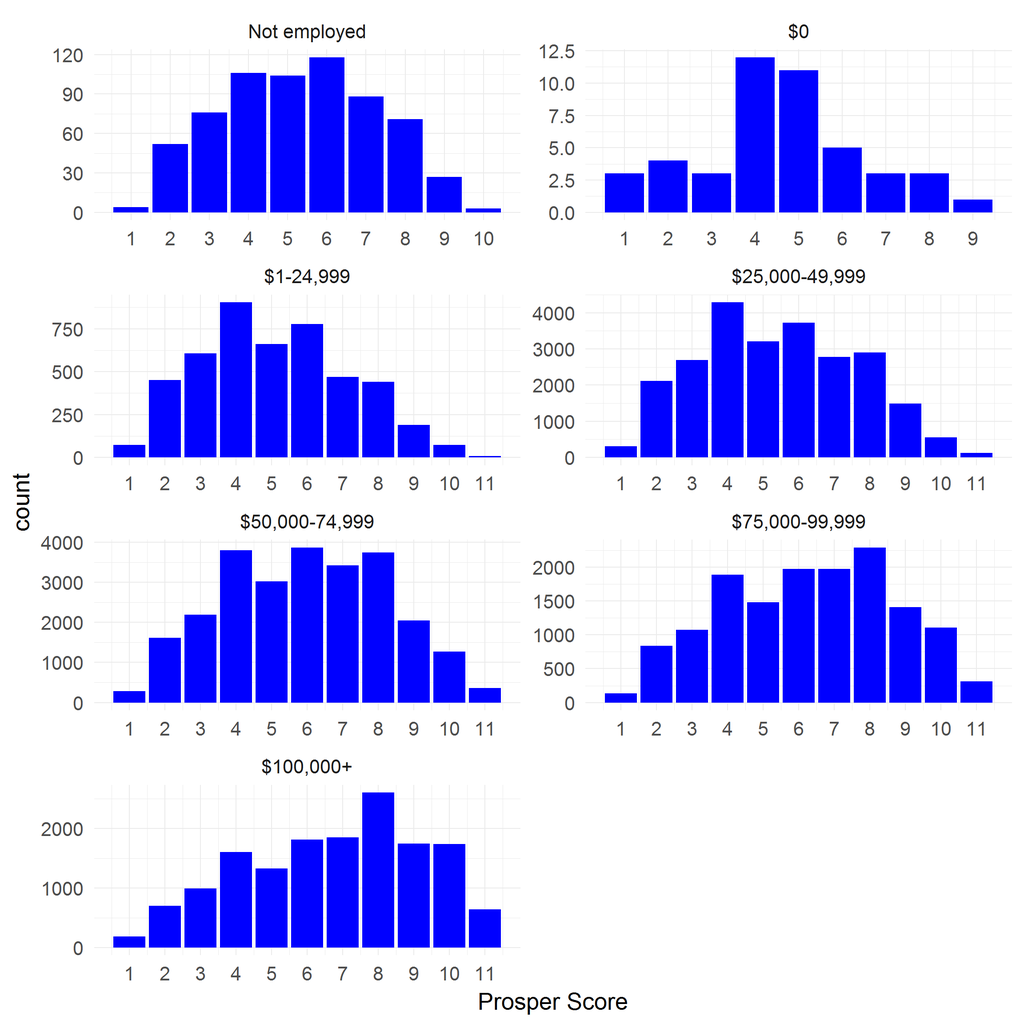

```
## loanData$IncomeRange: Not employed
##    Min. 1st Qu.  Median    Mean 3rd Qu.    Max.    NA's
##   1.000   4.000   5.000   5.308   7.000  10.000     157
## --------------------------------------------------------
## loanData$IncomeRange: $0
##    Min. 1st Qu.  Median    Mean 3rd Qu.    Max.    NA's
##     1.0     4.0     5.0     4.6     6.0     9.0     576
## --------------------------------------------------------
## loanData$IncomeRange: $1-24,999
##    Min. 1st Qu.  Median    Mean 3rd Qu.    Max.    NA's
##   1.000   4.000   5.000   5.093   7.000  11.000    2620
## --------------------------------------------------------
## loanData$IncomeRange: $25,000-49,999
##    Min. 1st Qu.  Median    Mean 3rd Qu.    Max.    NA's
##   1.000   4.000   5.000   5.424   7.000  11.000    8017
## --------------------------------------------------------
## loanData$IncomeRange: $50,000-74,999
##    Min. 1st Qu.  Median    Mean 3rd Qu.    Max.    NA's
##   1.000   4.000   6.000   5.957   8.000  11.000    5423
## --------------------------------------------------------
## loanData$IncomeRange: $75,000-99,999
##    Min. 1st Qu.  Median    Mean 3rd Qu.    Max.    NA's
##   1.000   4.000   6.000   6.297   8.000  11.000    2418
## --------------------------------------------------------
## loanData$IncomeRange: $100,000+
##    Min. 1st Qu.  Median    Mean 3rd Qu.    Max.    NA's
##   1.000   5.000   7.000   6.738   9.000  11.000    2132
```

**Are borrowers with a lower income spending more of their income on their loan?**

Borrowers with a stated monthly income of less than $500 have a high debt to income ratio, as the stated montly income increases we can see a significant fall in the debt to income ratio.

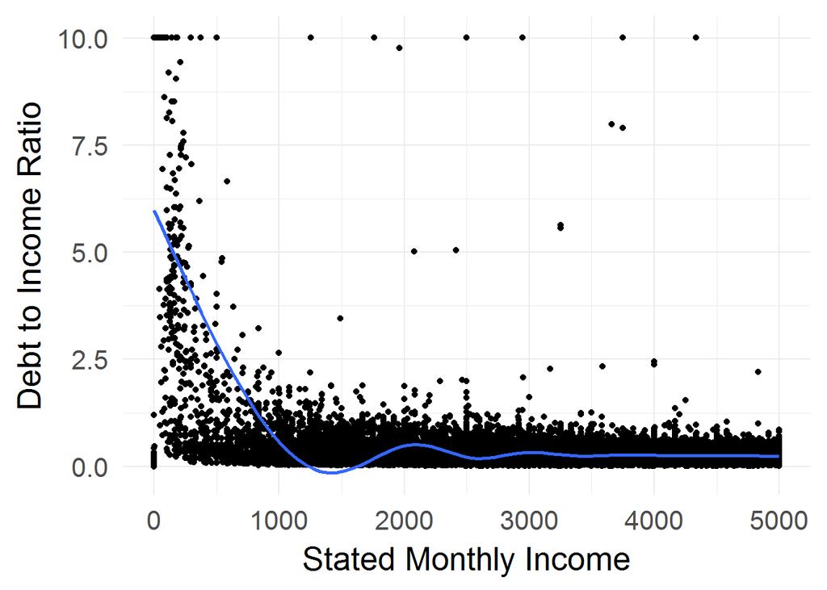

**Does the debt to income ratio have an effect on the Prosper Rating?**

Loans with a lower debt to income ratio have a higher Prosper rating on average, representing a lower risk loan. I will look into if having a low debt to income ratio and lower risk translates into a higher proportion of loans completing?

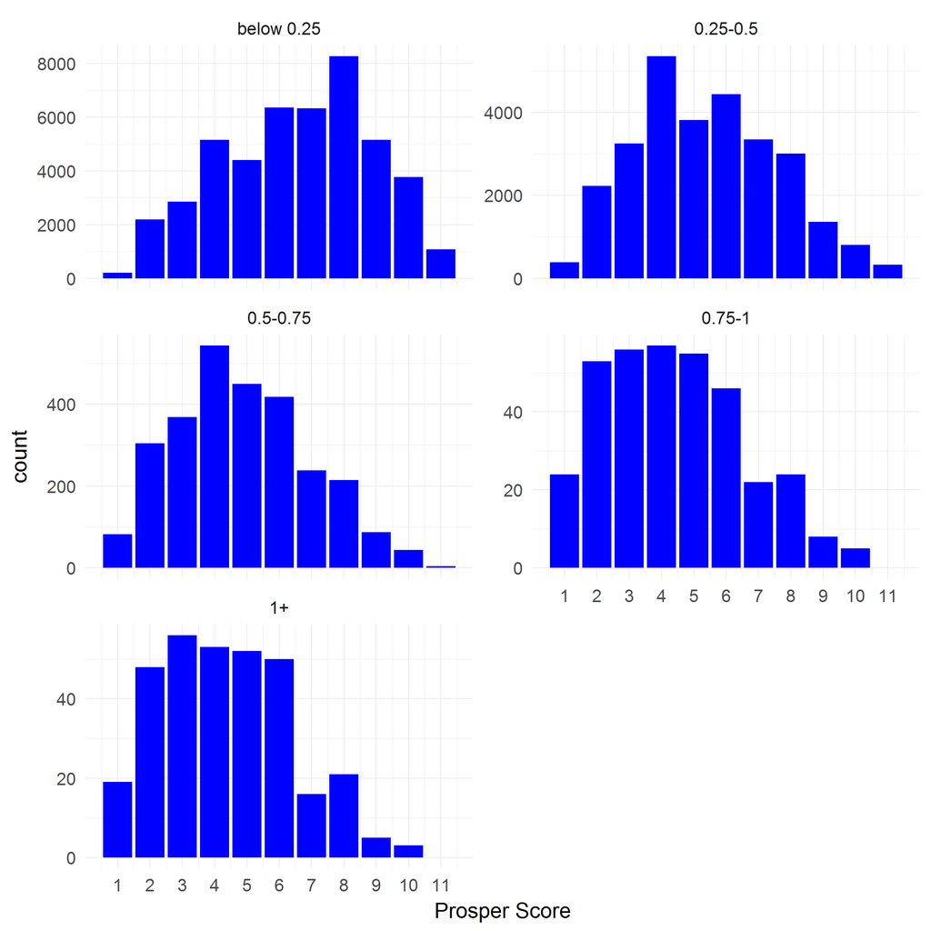

```
## loanData$DTI: below 0.25
##    Min. 1st Qu.  Median    Mean 3rd Qu.    Max.    NA's
##   1.000   3.000   5.000   4.366   6.000   7.000   18133
## --------------------------------------------------------
## loanData$DTI: 0.25-0.5
##    Min. 1st Qu.  Median    Mean 3rd Qu.    Max.    NA's
##   1.000   3.000   4.000   3.898   5.000   7.000    7856
## --------------------------------------------------------
## loanData$DTI: 0.5-0.75
##    Min. 1st Qu.  Median    Mean 3rd Qu.    Max.    NA's
##   1.000   2.000   3.000   3.054   4.000   7.000    1138
## --------------------------------------------------------
## loanData$DTI: 0.75-1
##    Min. 1st Qu.  Median    Mean 3rd Qu.    Max.    NA's
##   1.000   1.000   2.000   2.489   3.000   7.000     223
## --------------------------------------------------------
## loanData$DTI: 1+
##    Min. 1st Qu.  Median    Mean 3rd Qu.    Max.    NA's
##   1.000   1.000   2.000   2.328   3.000   7.000     476
```

**Do loans with a lower debt to income ratio have a higher proportion of completing loans?**

Loans with a lower debt to income ratio have a higher proportion of loans that complete, while loans with a higher debt to income ratio have a higher proportion of loans that are charged off and defaulted.

Once again, for the next few plots I have taken out loans with a status as ‘Current’ this is because I would like to better understand the factors that effect the outcome of the loan.

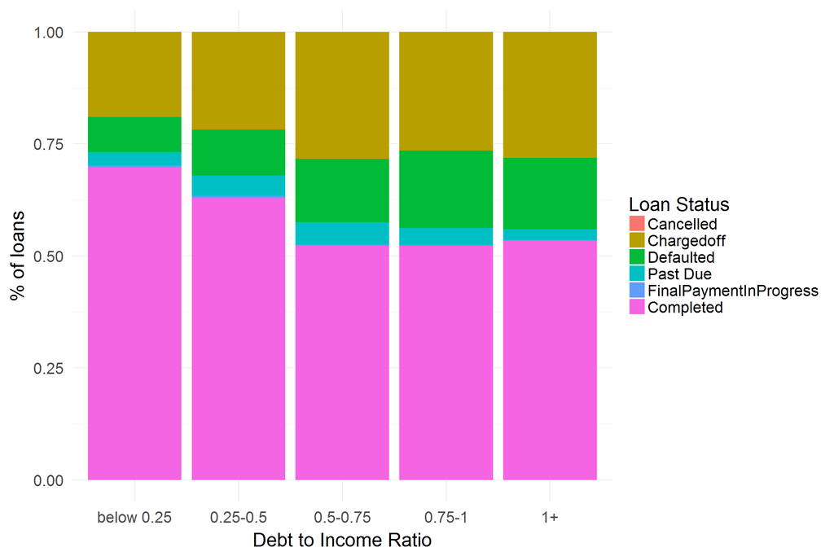

**Do loans with a higher Prosper rating have a higher completion rate?**

We can see a similar trend when looking at the Prosper Score. That is to say, loans with a higher Prosper score (indicating lower risk) recorded a higher proportion of completed loans. Loans with higher risk recorded a higher proportion of charged off and defaulted loans.

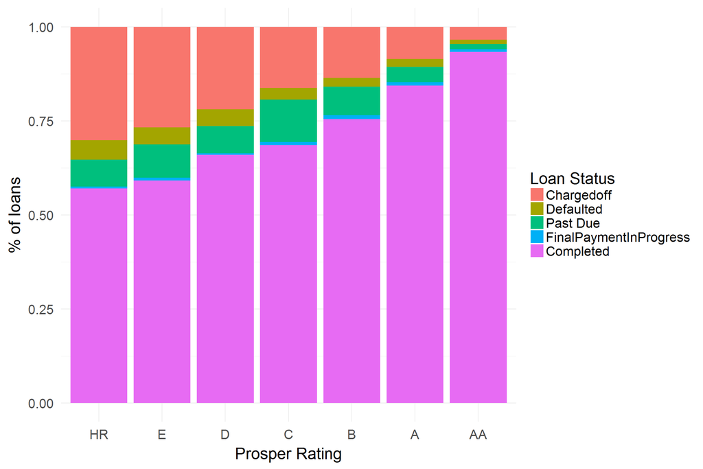

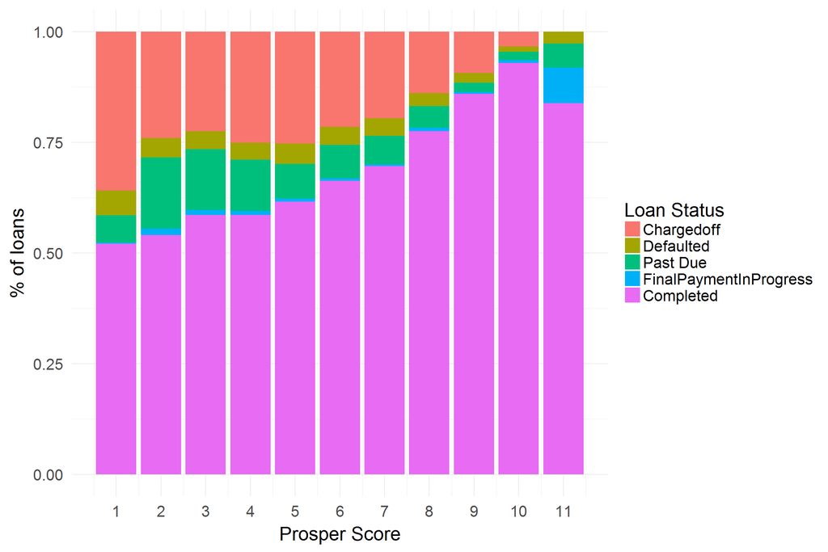

**Risk Summary**

So far I have focused on loan characteristics associated with the risk of the loan.

There are a number of loan characteristics that are categorised as having a higher risk. Employment status and debt to income ratio have an effect on both the rating and outcome of the loans.

The analysis so far has shown that loans with a higher risk rating have a higher proportion of loans with a status of charged off, past due and defaulted. Furthermore, the ratings seem to be accurately indicating the risk of loans with lower risk loans recording a higher proportion of completions.

# What loan characteristics result in a higher lender yield?

**Lender Yield by Year**

I was curious to see if the average lender yield would change over time. Would the lender yield increase as the company became more establised and sophisticated? Or remain stable over time?

To a point the average lender yield increased over the life of the company, peaking in 2011. However, post 2011 the average lender yield showed a steady decline to 2014.

I decided to look at the average debt to income ratio by year to see if any additional patterns emerged. Interestingly the debt to income ratio was highest in 2007, right before the Global Financial Crisis of 2007 - 2009. From 2010 the average debt to income ratio remained relatively stable.

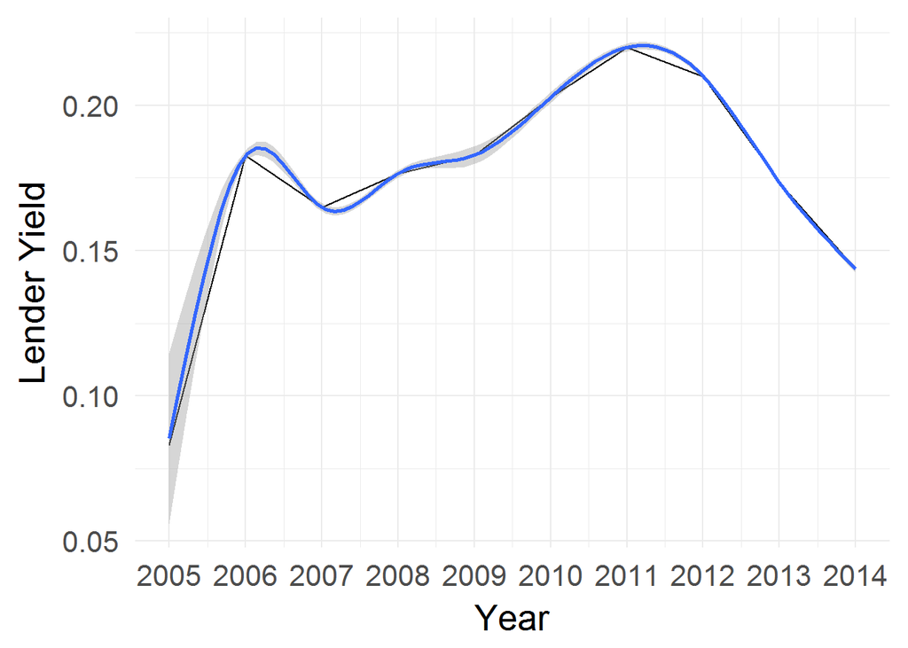

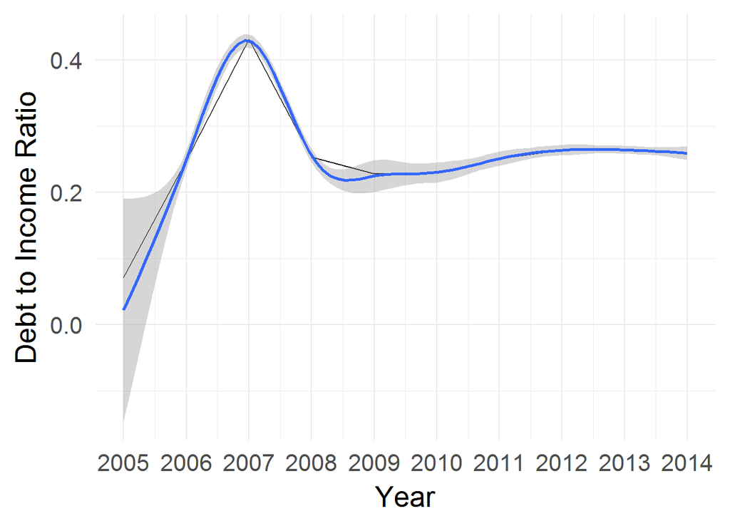

**Does estimated yield accurately predict lender yield?**

When we plot the estimated effective yield to the lender yield we can see that for the large majority of loans, the lender yield outperformed the estaimted effective yield.

The line shows where estimated effective yield is equal to lender yield.

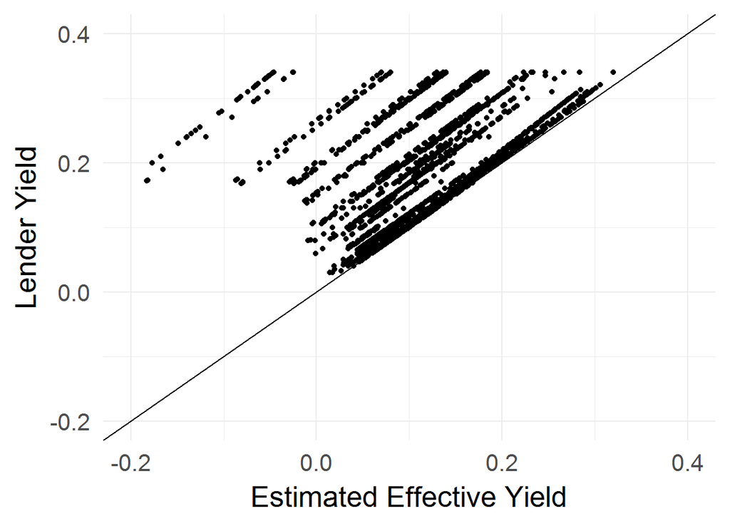

**What is the lender yield by income range?**